# Sentiment Analysis for GM Tweets & Relationship with Daily Stock Price Change

Li Peishan

```r
knitr::opts_chunk$set(echo = TRUE,eval=TRUE, message=FALSE, warning=FALSE)
```

Load packages:

```r
library(readxl)
library(magrittr)
library(dplyr)
library(ggplot2)
library(ggmap)
library(ggthemes)
library(ggpubr)
library(ggforce)
library(tidyverse)
library(gmodels)
library(rgdal)
library(osmdata)
library(nominatim)
library(jsonlite)
library(RColorBrewer)
library(tidyr)
library(leaflet)
library(maps)
library(tigris)
library(tidytext)
library(textdata)
library(tm)
library(quanteda)
library(rvest)
library(stringr)
library(SnowballC)
library(wordcloud)
library(plotrix)
library(qdapDictionaries)
library(formattable)
library(stringr)
library(DT)
```

Import database:

```r
GM<-read.csv("/Users/annie/Desktop/Columbia Fall2021/Columbia Course Fall 2021/GR5067 NLP/Group Project/GM_stock_sentiment_analysis.csv")
```

# Cleaning the text and word cloud

## Text cleaning–Further remove numbers and punctuations

Create and preprocess text in corpus (162 tweets)

```r
doc_id<-c(1:162)
line<-c(rep(1,162))
text<-data.frame(doc_id, text=GM$tweet,line, stringsAsFactors=FALSE)
df_source<-DataframeSource(text)
df_corpus<-VCorpus(df_source)
#Clean text
#removefullycap<-function(x){gsub("[A-Z][A-Z]+", " ", x)}
#removeemoji<-function(x){gsub("[^\x01-\x7F]", "", x)}
clean_corpus<-function(corpus){
  #corpus<-tm_map(corpus, content_transformer(removefullycap))
  #corpus<-tm_map(corpus, content_transformer(removeemoji))
  #corpus<-tm_map(corpus, content_transformer(tolower))
  #corpus<-tm_map(corpus, removeWords, c(stopwords("en")))
  corpus<-tm_map(corpus, removeNumbers)
  corpus<-tm_map(corpus, removePunctuation)
  corpus<-tm_map(corpus, stripWhitespace)
  return(corpus)
}
corpus_clean<-clean_corpus(df_corpus)
corpus_dtm<-DocumentTermMatrix(corpus_clean)
corpus_m<-as.matrix(corpus_dtm)
corpus_dtm
```

```
<<DocumentTermMatrix (documents: 162, terms: 973)>>
Non-/sparse entries: 2021/155605
Sparsity           : 99%
Maximal term length: 20
Weighting          : term frequency (tf)
```

```r
dim(corpus_m)
```

```
[1] 162 973
```

## Word cloud

Calculate tf_itf scores for tweets.

```r
#Tidy objects
corpustd<-tidy(corpus_dtm)
#Calculate frequencies
corpustf_idf<-corpustd %>%
  bind_tf_idf(term, document, count) %>%
  arrange(desc(tf_idf))
corpustf_idf
```

| document | term | count | tf | idf | tf_idf |
| --- | --- | --- | --- | --- | --- |
| 108 | lovewins | 1 | 1.00000000 | 5.087596 | 5.0875963 |
| 104 | here | 1 | 1.00000000 | 3.988984 | 3.9889840 |
| 127 | love | 1 | 1.00000000 | 3.988984 | 3.9889840 |
| 30 | chaseelliott | 1 | 0.33333333 | 5.087596 | 1.6958654 |
| 30 | teamchevy | 1 | 0.33333333 | 5.087596 | 1.6958654 |
| 80 | kimberlyeber | 1 | 0.33333333 | 5.087596 | 1.6958654 |
| 87 | crackthecode | 1 | 0.33333333 | 5.087596 | 1.6958654 |
| 87 | discussion | 1 | 0.33333333 | 3.988984 | 1.3296613 |
| 89 | steve | 1 | 0.25000000 | 5.087596 | 1.2718991 |
| 137 | ceomikejackson | 1 | 0.25000000 | 5.087596 | 1.2718991 |

[output cut: 990 more lines]

Word cloud for GM CEO’s tweets

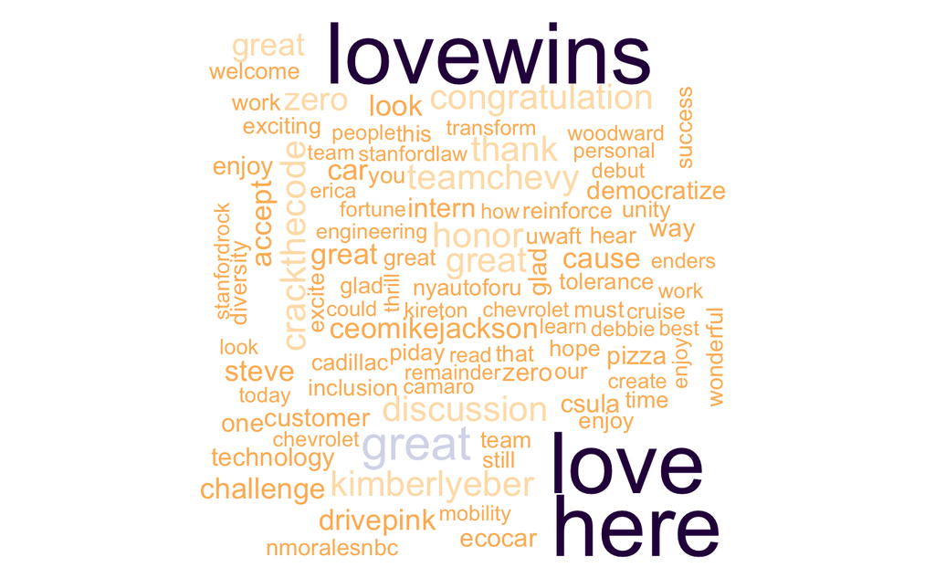

```r
purple_orange<-brewer.pal(10, "PuOr")
purple_orange<-purple_orange[-(1:2)]
set.seed(2100)
wordcloud(corpustf_idf$term, corpustf_idf$tf, max.words=100, colors=purple_orange)
```

# Sentiment

## (a) Stay positive

Calculate the tone of each text based on the positive and negative words that are being used in the tweets.

First build the sentiment function. Obtain the list of `positive.words` and `negative.words` from the sentiment dictionary of Hu & Liu (2004) using the `qdapDictionaries` package.

```r
sentiment<-function(words=c("really great good stuff bad")){
  tok<-tokens(words)
  pos.count<-sum(tok[[1]] %in% positive.words)
  #cat("\n positive words:",tok[[1]][which(tok[[1]]%in%positive.words)],"\n")
  neg.count<-sum(tok[[1]]%in%negative.words)
  #cat("\n negative words:",tok[[1]][which(tok[[1]]%in%negative.words)],"\n")
  out<-(pos.count-neg.count)/(pos.count+neg.count)
  #cat("\n Tone of Document:",out)
  return(out)
}
```

Apply the function on text of the 162 tweets.

```r
toneofdocument<-GM
toneofdocument<-toneofdocument
for (i in 1:162){
  toneofdocument$toneofdocument[i]<-sentiment(toneofdocument$tweet[i])
}
toneofdocument
```

| X | tweet | created_at..after.trading.hours. | Same.day.stock.closing.price | Next.day.stock.open.price | Daily.change | toneofdocument |
| --- | --- | --- | --- | --- | --- | --- |
| 0 | ['it', 'excite', 'day', 'welcome', 'potus', 'factory', 'zero', 'we', 'thrill', 'experience', 'gmc', 'hummer', 'ev', 'pickup', 'importantly', 'meet', 'outstanding', 'manufacture', 'team', 'heart', 'ope… | 2021-11-17 23:37:07+00:00 | 64.61 | 64.33 | -0.43% | 1.0000000 |
| 1 | ['wish', 'randy', 'mott', 'wonderful', 'retirement', 'congratulation', 'fred', 'killeen', 'stacy', 'lynett', 'new', 'role', 'restructure', 'global', 'it', 'teams'] | 2021-11-10 17:05:15+00:00 | 59.27 | 59.82 | 0.93% | 1.0000000 |
| 2 | ['congratulation', 'commercegov', 'secraimondo', 'new', 'chair', 'uspto', 'council', 'inclusive', 'innovation', 'ci2', 'i', 'look', 'forward', 'work', 'together', 'drive', 'equality', 'world', 'innova… | 2021-10-28 20:04:51+00:00 | 54.24 | 53.90 | -0.63% | 1.0000000 |
| 3 | ['congratulation', 'gm', 'deborahwahl', 'name', 'one', 'world', 'mostinfluentialcmos', 'forbes', 'thank', 'help', 'u', 'bring', 'everybodyin'] | 2021-09-30 17:12:19+00:00 | 52.71 | 53.03 | 0.61% | 1.0000000 |
| 4 | ['great', 'discussion', 'alansmurray', 'gm', 'bold', 'ambition', 'lead', 'industry', 'electric', 'future', 'this', 'exciting', 'time', 'industry', 'i', 'appreciate', 'workdayevents', 'wdayconversation… | 2021-09-28 23:11:23+00:00 | 52.85 | 53.30 | 0.85% | 1.0000000 |
| 5 | ['it', 'important', 'invest', 'amp', 'implement', 'solution', 'community', 'live', 'work', 'ensure', 'leave', 'anyone', 'behind', 'i', 'speak', 'hometown', 'mayormikeduggan', '50m', 'investment', 'non… | 2021-09-14 18:41:35+00:00 | 50.74 | 50.79 | 0.10% | 1.0000000 |
| 6 | ['davidwestin', 'thanks', 'spending', 'time', 'hometown', 'headquarters', 'it', 'great', 'discuss', 'transform', 'industry', 'ev', 'av', 'expand', 'software', 'strategy', 'proud', 'i', 'talented', 'gm… | 2021-08-26 19:35:00+00:00 | 48.62 | 48.75 | 0.27% | 1.0000000 |
| 7 | ['thanks', 'today', 'lebeaucarnews', 'discuss', 'gm', 'record', 'result', 'q2', 'strong', 'first', 'half', 'year', 'i', 'look', 'forward', 'share', 'excite', 'ev', 'product', 'portfolio', 'coming', 'm… | 2021-08-04 19:38:06+00:00 | 52.72 | 53.86 | 2.16% | 1.0000000 |
| 8 | ['evs', 'gina', 'we', 'love', 'ride', 'at', 'gm', 'want', 'bring', 'everybodyin', 'electric', 'future', 'include', 'create', 'evs', 'affordable', 'stylish', 'especially', 'fun', 'drive', 'the', 'bipar… | 2021-07-01 16:35:36+00:00 | 59.11 | 59.11 | 0.00% | 1.0000000 |
| 9 | ['i', 'excite', 'future', 'one', 'bring', 'everybodyin', 'gm', 'company', 'big', 'thing', 'investment', 'help', 'create', 'inclusive', 'sustainable', 'world', 'want', 'deserve'] | 2021-06-29 23:50:18+00:00 | 58.83 | 58.74 | -0.15% | 1.0000000 |

[output cut: 152 more lines]

```r
write.csv(toneofdocument,"/Users/annie/Desktop/Columbia Fall2021/Columbia Course Fall 2021/GR5067 NLP/Group Project/GM tone of document.csv", row.names = FALSE)
```

Visualize the relationship between tone of the document and daily stock price change.

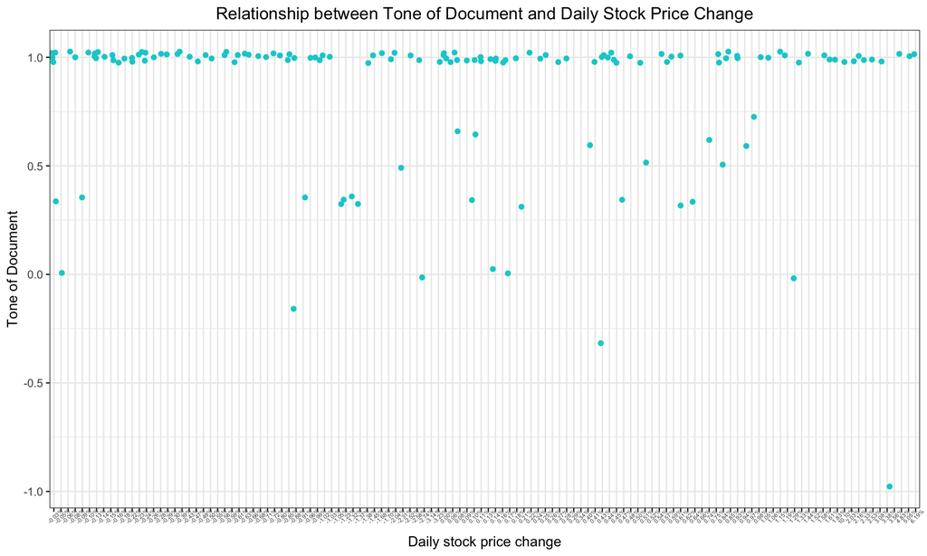

```r
plot<-toneofdocument %>%
  ggplot(aes(x=toneofdocument,y=Daily.change))+
  geom_jitter(color="#00CED1")+
  theme_bw()+
  theme(legend.position="none")+
  labs(x="Tone of Document", y="Daily stock price change", title="Relationship between Tone of Document and Daily Stock Price Change")+
  theme(plot.title=element_text(hjust=0.5))+
  theme(axis.text.x=element_text(hjust=0.5, angle=45,size=4.5))+
  coord_flip()
plot
```

## (b) Positive VS Negative

Ignore all documents that do not have words contained within the Hu & Liu dictionary and all neutral scores. Collapse the positive and negative texts into two larger documents.

```r
positivetone<-toneofdocument %>%
  filter(toneofdocument>0) %>%
  select(tweet)
positivetext<-paste(unlist(positivetone$tweet), collapse=" ")
negativetone<-toneofdocument %>%
  filter(toneofdocument<0) %>%
  select(tweet)
negativetext<-paste(unlist(negativetone$tweet), collapse=" ")
```

### Comparison Wordcloud

Generate comparison cloud showing the most-frequent positive and negative words, where document 1 denotes positive texts, and document 2 denotes negative texts.

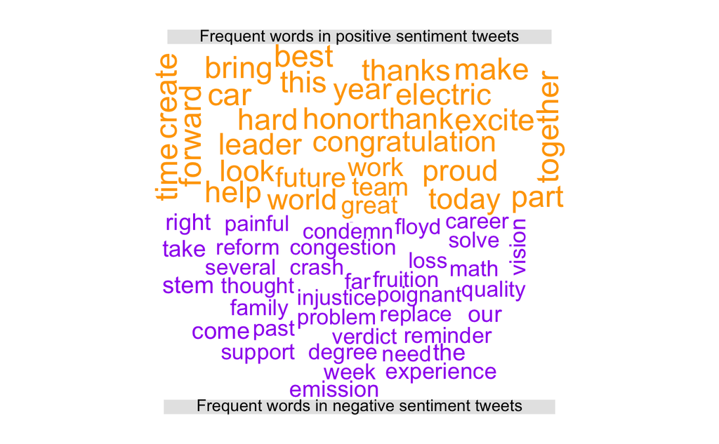

```r
doc_id<-c("Frequent words in positive sentiment tweets","Frequent words in negative sentiment tweets")
line<-c(1,1)
comparisontext<-data.frame(doc_id, text=c(positivetext, negativetext),line, stringsAsFactors=FALSE)
df_source<-DataframeSource(comparisontext)
df_corpus<-VCorpus(df_source)
corpuscomparison_clean<-clean_corpus(df_corpus)
corpuscomparison_tdm<-TermDocumentMatrix(corpuscomparison_clean)
corpuscomparison_m<-as.matrix(corpuscomparison_tdm)
set.seed(2105)
comparison.cloud(corpuscomparison_m, colors=c("orange", "purple"), scale=c(0.1,2), title.size=1, max.words=100)
```

## (c) Get in their mind

```r
nrc_anger<-get_sentiments("nrc") %>%
  filter(sentiment=="anger")
nrc_anticipation<-get_sentiments("nrc") %>%
  filter(sentiment=="anticipation")
nrc_disgust<-get_sentiments("nrc") %>%
  filter(sentiment=="disgust")
nrc_fear<-get_sentiments("nrc") %>%
  filter(sentiment=="fear")
nrc_joy<-get_sentiments("nrc") %>%
  filter(sentiment=="joy")
nrc_sadness<-get_sentiments("nrc") %>%
  filter(sentiment=="sadness")
nrc_surprise<-get_sentiments("nrc") %>%
  filter(sentiment=="surprise")
nrc_trust<-get_sentiments("nrc") %>%
  filter(sentiment=="trust")
nrc_negative<-get_sentiments("nrc") %>%
  filter(sentiment=="negative")
nrc_positive<-get_sentiments("nrc") %>%
  filter(sentiment=="positive")
```

Prepare corpus for identifying emotions.

For tweets that are associated with daily stock price increase/decrease:

```r
iGM<-GM %>%
  filter(Daily.change>0)
dGM<-GM %>%
  filter(Daily.change<0)
```

```r
#Increasing daily stock prices
doc_id<-c(1:89)
line<-c(rep(1,89))
text<-data.frame(doc_id, text=c(iGM$tweet),line, stringsAsFactors=FALSE)
i_df_source<-DataframeSource(text)
i_df_nrc<-VCorpus(i_df_source)
i_nrc_clean<-clean_corpus(i_df_nrc)
i_nrc_dtm<-DocumentTermMatrix(i_nrc_clean)
i_nrc_m<-as.matrix(i_nrc_dtm)
i_nrc_td<-tidy(i_nrc_dtm)
i_nrc_tf_idf<-i_nrc_td %>%
  bind_tf_idf(term, document, count)
i_nrc_tf_idf<-i_nrc_tf_idf %>%
  arrange(desc(tf_idf))
i_nrc_tf_idf
```

| document | term | count | tf | idf | tf_idf |
| --- | --- | --- | --- | --- | --- |
| 56 | here | 1 | 1.00000000 | 3.390024 | 3.3900241 |
| 20 | chaseelliott | 1 | 0.33333333 | 4.488636 | 1.4962121 |
| 20 | teamchevy | 1 | 0.33333333 | 4.488636 | 1.4962121 |
| 45 | kimberlyeber | 1 | 0.33333333 | 4.488636 | 1.4962121 |
| 50 | crackthecode | 1 | 0.33333333 | 4.488636 | 1.4962121 |
| 50 | discussion | 1 | 0.33333333 | 3.390024 | 1.1300080 |
| 72 | accept | 1 | 0.25000000 | 4.488636 | 1.1221591 |
| 72 | ceomikejackson | 1 | 0.25000000 | 4.488636 | 1.1221591 |
| 72 | drivepink | 1 | 0.25000000 | 4.488636 | 1.1221591 |
| 45 | honor | 1 | 0.33333333 | 2.879198 | 0.9597328 |

[output cut: 990 more lines]

```r
#Decreasing daily stock prices
doc_id<-c(1:73)
line<-c(rep(1,73))
text<-data.frame(doc_id, text=c(dGM$tweet),line, stringsAsFactors=FALSE)
d_df_source<-DataframeSource(text)
d_df_nrc<-VCorpus(d_df_source)
d_nrc_clean<-clean_corpus(d_df_nrc)
d_nrc_dtm<-DocumentTermMatrix(d_nrc_clean)
d_nrc_m<-as.matrix(d_nrc_dtm)
d_nrc_td<-tidy(d_nrc_dtm)
d_nrc_tf_idf<-d_nrc_td %>%
  bind_tf_idf(term, document, count)
d_nrc_tf_idf<-d_nrc_tf_idf %>%
  arrange(desc(tf_idf))
d_nrc_tf_idf
```

| document | term | count | tf | idf | tf_idf |
| --- | --- | --- | --- | --- | --- |
| 51 | lovewins | 1 | 1.00000000 | 4.290459 | 4.29045944 |
| 62 | love | 1 | 1.00000000 | 3.597312 | 3.59731226 |
| 38 | steve | 1 | 0.25000000 | 4.290459 | 1.07261486 |
| 56 | cause | 1 | 0.25000000 | 3.597312 | 0.89932807 |
| 60 | csula | 1 | 0.20000000 | 4.290459 | 0.85809189 |
| 60 | ecocar | 1 | 0.20000000 | 4.290459 | 0.85809189 |
| 60 | pizza | 1 | 0.20000000 | 4.290459 | 0.85809189 |
| 48 | intern | 2 | 0.22222222 | 3.597312 | 0.79940272 |
| 56 | car | 1 | 0.25000000 | 3.191847 | 0.79796179 |
| 56 | great | 2 | 0.50000000 | 1.517871 | 0.75893536 |

[output cut: 892 more lines]

### Angry

Find tf_idf score for angry words used in the tweets.

```r
ianger<-i_nrc_tf_idf %>%
  filter(term %in% nrc_anger$word) %>%
  select(term,tf_idf)
ianger<-rename(ianger, i_tf_idf=tf_idf)
danger<-d_nrc_tf_idf %>%
  filter(term %in% nrc_anger$word) %>%
  select(term,tf_idf)
danger<-rename(danger, d_tf_idf=tf_idf)
angerwords<-full_join(ianger, danger,by="term")
#Replace all NA values as 0
angerwords$i_tf_idf[is.na(angerwords$i_tf_idf)]<-0
angerwords$d_tf_idf[is.na(angerwords$d_tf_idf)]<-0
angerwords
```

| term | i_tf_idf | d_tf_idf |
| --- | --- | --- |
| challenge | 0.9488723 | 0.0000000 |
| honest | 0.5610795 | 0.0000000 |
| defiance | 0.4987374 | 0.0000000 |
| deserve | 0.4217210 | 0.2767163 |
| deserve | 0.4217210 | 0.2248320 |
| tackle | 0.3206169 | 0.0000000 |
| challenge | 0.3036391 | 0.0000000 |
| excite | 0.2879198 | 0.4840275 |
| excite | 0.2879198 | 0.1815103 |
| excite | 0.2879198 | 0.1613425 |

[output cut: 28 more lines]

Visualize the relationship between the use of words from the angry category and stock price change.

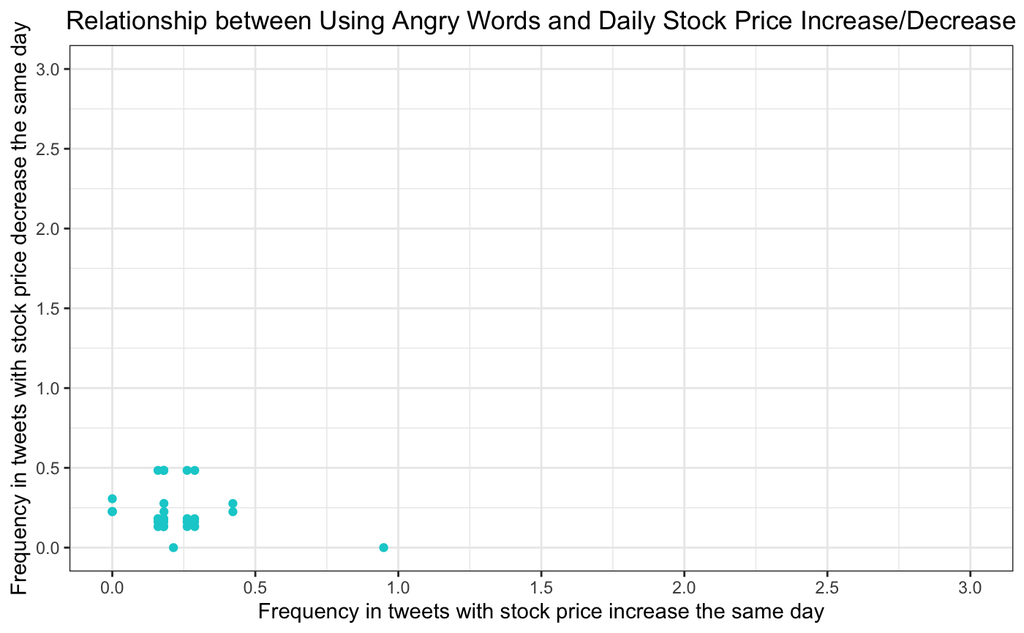

```r
plot2<-angerwords %>%
  ggplot(aes(x=i_tf_idf,y=d_tf_idf))+
  geom_jitter(color="#00CED1")+
  theme_bw()+
  theme(legend.position="none")+
  labs(x="Frequency in tweets with stock price increase the same day", y="Frequency in tweets with stock price decrease the same day", title="Relationship between Using Angry Words and Daily Stock Price Increase/Decrease")+
  theme(plot.title=element_text(hjust=0.5))+
  scale_x_continuous(limits=c(0,3), breaks=seq(0,3,0.5))+
  scale_y_continuous(limits=c(0,3), breaks=seq(0,3,0.5))#+
  #facet_zoom(x=i_tf_idf<=0.5, y=d_tf_idf<=0.5)
plot2
```

### Anticipation

Find tf_idf score for anticipation words used in the tweets.

```r
ianticipation<-i_nrc_tf_idf %>%
  filter(term %in% nrc_anticipation$word) %>%
  select(term,tf_idf)
ianticipation<-rename(ianticipation, i_tf_idf=tf_idf)
danticipation<-d_nrc_tf_idf %>%
  filter(term %in% nrc_anticipation$word) %>%
  select(term,tf_idf)
danticipation<-rename(danticipation, d_tf_idf=tf_idf)
anticipationwords<-full_join(ianticipation, danticipation,by="term")
#Replace all NA values as 0
anticipationwords$i_tf_idf[is.na(anticipationwords$i_tf_idf)]<-0
anticipationwords$d_tf_idf[is.na(anticipationwords$d_tf_idf)]<-0
anticipationwords
```

| term | i_tf_idf | d_tf_idf |
| --- | --- | --- |
| fortune | 0.6412338 | 0.3300353 |
| hire | 0.6412338 | 0.0000000 |
| holiday | 0.5610795 | 0.0000000 |
| hope | 0.5610795 | 0.5995520 |
| hope | 0.5610795 | 0.2997760 |
| seek | 0.5610795 | 0.0000000 |
| glad | 0.4744361 | 0.5362043 |
| glad | 0.4744361 | 0.4468369 |
| glad | 0.4744361 | 0.3351277 |
| glad | 0.4744361 | 0.2978913 |

[output cut: 233 more lines]

Visualize the relationship between the use of words from the anticipation category and stock price change.

[figure not shown]

```r
plot3<-anticipationwords %>%
  ggplot(aes(x=i_tf_idf,y=d_tf_idf))+
  geom_jitter(color="#00CED1")+
  theme_bw()+
  theme(legend.position="none")+
  labs(x="Frequency in tweets with stock price increase the same day", y="Frequency in tweets with stock price decrease the same day", title="Relationship between Using Angry Words and Daily Stock Price Increase/Decrease")+
  theme(plot.title=element_text(hjust=0.5))+
  scale_x_continuous(limits=c(0,3), breaks=seq(0,3,0.5))+
  scale_y_continuous(limits=c(0,3), breaks=seq(0,3,0.5))
plot3
```

### Disgust

Find tf_idf score for disgust words used in the tweets.

```r
idisgust<-i_nrc_tf_idf %>%
  filter(term %in% nrc_disgust$word) %>%
  select(term,tf_idf)
idisgust<-rename(idisgust, i_tf_idf=tf_idf)
ddisgust<-d_nrc_tf_idf %>%
  filter(term %in% nrc_disgust$word) %>%
  select(term,tf_idf)
ddisgust<-rename(ddisgust, d_tf_idf=tf_idf)
disgustwords<-full_join(idisgust, ddisgust,by="term")
#Replace all NA values as 0
disgustwords$i_tf_idf[is.na(disgustwords$i_tf_idf)]<-0
disgustwords$d_tf_idf[is.na(disgustwords$d_tf_idf)]<-0
disgustwords
```

| term | i_tf_idf | d_tf_idf |
| --- | --- | --- |
| honest | 0.5610795 | 0.0000000 |
| defiance | 0.4987374 | 0.0000000 |
| waste | 0.3452797 | 0.0000000 |
| humble | 0.2640374 | 0.4290459 |
| contagious | 0.0000000 | 0.4767177 |
| painful | 0.0000000 | 0.2258137 |
| excellence | 0.0000000 | 0.2043076 |

Visualize the relationship between the use of words from the disgust category and stock price change

[figure not shown]

```r
plot4<-disgustwords %>%
  ggplot(aes(x=i_tf_idf,y=d_tf_idf))+
  geom_jitter(color="#00CED1")+
  theme_bw()+
  theme(legend.position="none")+
  labs(x="Frequency in tweets with stock price increase the same day", y="Frequency in tweets with stock price decrease the same day", title="Relationship between Using Angry Words and Daily Stock Price Increase/Decrease")+
  theme(plot.title=element_text(hjust=0.5))+
  scale_x_continuous(limits=c(0,2), breaks=seq(0,2,0.5))+
  scale_y_continuous(limits=c(0,2), breaks=seq(0,2,0.5))
plot4
```

### Fear

Find tf_idf score for fear words used in the tweets.

```r
ifear<-i_nrc_tf_idf %>%
  filter(term %in% nrc_fear$word) %>%
  select(term,tf_idf)
ifear<-rename(ifear, i_tf_idf=tf_idf)
dfear<-d_nrc_tf_idf %>%
  filter(term %in% nrc_fear$word) %>%
  select(term,tf_idf)
dfear<-rename(dfear, d_tf_idf=tf_idf)
fearwords<-full_join(ifear, dfear,by="term")
#Replace all NA values as 0
fearwords$i_tf_idf[is.na(fearwords$i_tf_idf)]<-0
fearwords$d_tf_idf[is.na(fearwords$d_tf_idf)]<-0
fearwords
```

| term | i_tf_idf | d_tf_idf |
| --- | --- | --- |
| challenge | 0.9488723 | 0.0000000 |
| honest | 0.5610795 | 0.0000000 |
| defiance | 0.4987374 | 0.0000000 |
| pandemic | 0.4488636 | 0.0000000 |
| crash | 0.4488636 | 0.2860306 |
| problem | 0.4488636 | 0.0000000 |
| thrill | 0.4488636 | 0.5139018 |
| thrill | 0.4488636 | 0.1998507 |
| injured | 0.4080579 | 0.0000000 |
| change | 0.3447047 | 0.2767163 |

[output cut: 52 more lines]

Visualize the relationship between the use of words from the fear category and stock price change.

[figure not shown]

```r
plot5<-fearwords %>%
  ggplot(aes(x=i_tf_idf,y=d_tf_idf))+
  geom_jitter(color="#00CED1")+
  theme_bw()+
  theme(legend.position="none")+
  labs(x="Frequency in tweets with stock price increase the same day", y="Frequency in tweets with stock price decrease the same day", title="Relationship between Using Angry Words and Daily Stock Price Increase/Decrease")+
  theme(plot.title=element_text(hjust=0.5))+
  scale_x_continuous(limits=c(0,2), breaks=seq(0,2,0.5))+
  scale_y_continuous(limits=c(0,2), breaks=seq(0,2,0.5))
plot5
```

### Joy

Find tf_idf score for joy words used in the tweets.

```r
ijoy<-i_nrc_tf_idf %>%
  filter(term %in% nrc_joy$word) %>%
  select(term,tf_idf)
ijoy<-rename(ijoy, i_tf_idf=tf_idf)
djoy<-d_nrc_tf_idf %>%
  filter(term %in% nrc_joy$word) %>%
  select(term,tf_idf)
djoy<-rename(djoy, d_tf_idf=tf_idf)
joywords<-full_join(ijoy, djoy,by="term")
#Replace all NA values as 0
joywords$i_tf_idf[is.na(joywords$i_tf_idf)]<-0
joywords$d_tf_idf[is.na(joywords$d_tf_idf)]<-0
joywords
```

| term | i_tf_idf | d_tf_idf |
| --- | --- | --- |
| fortune | 0.6412338 | 0.3300353 |
| hire | 0.6412338 | 0.0000000 |
| holiday | 0.5610795 | 0.0000000 |
| accomplish | 0.5610795 | 0.0000000 |
| hope | 0.5610795 | 0.5995520 |
| hope | 0.5610795 | 0.2997760 |
| honest | 0.5610795 | 0.0000000 |
| glad | 0.4744361 | 0.5362043 |
| glad | 0.4744361 | 0.4468369 |
| glad | 0.4744361 | 0.3351277 |

[output cut: 238 more lines]

Visualize the relationship between the use of words from the joy category and stock price change.

[figure not shown]

```r
plot6<-joywords %>%
  ggplot(aes(x=i_tf_idf,y=d_tf_idf))+
  geom_jitter(color="#00CED1")+
  theme_bw()+
  theme(legend.position="none")+
  labs(x="Frequency in tweets with stock price increase the same day", y="Frequency in tweets with stock price decrease the same day", title="Relationship between Using Angry Words and Daily Stock Price Increase/Decrease")+
  theme(plot.title=element_text(hjust=0.5))+
  scale_x_continuous(limits=c(0,3), breaks=seq(0,3,0.5))+
  scale_y_continuous(limits=c(0,3), breaks=seq(0,3,0.5))
plot6
```

### Sadness

Find tf_idf score for sadness words used in the tweets.

```r
isadness<-i_nrc_tf_idf %>%
  filter(term %in% nrc_sadness$word) %>%
  select(term,tf_idf)
isadness<-rename(isadness, i_tf_idf=tf_idf)
dsadness<-d_nrc_tf_idf %>%
  filter(term %in% nrc_sadness$word) %>%
  select(term,tf_idf)
dsadness<-rename(dsadness, d_tf_idf=tf_idf)
sadnesswords<-full_join(isadness, dsadness,by="term")
#Replace all NA values as 0
sadnesswords$i_tf_idf[is.na(sadnesswords$i_tf_idf)]<-0
sadnesswords$d_tf_idf[is.na(sadnesswords$d_tf_idf)]<-0
sadnesswords
```

| term | i_tf_idf | d_tf_idf |
| --- | --- | --- |
| honest | 0.5610795 | 0.0000000 |
| pandemic | 0.4488636 | 0.0000000 |
| crash | 0.4488636 | 0.2860306 |
| problem | 0.4488636 | 0.0000000 |
| terrific | 0.4488636 | 0.3997014 |
| terrific | 0.4488636 | 0.3270284 |
| injured | 0.4080579 | 0.0000000 |
| surgery | 0.3206169 | 0.0000000 |
| retirement | 0.2992424 | 0.2145230 |
| humble | 0.2640374 | 0.4290459 |

[output cut: 6 more lines]

Visualize the relationship between the use of words from the sadness category and stock price change.

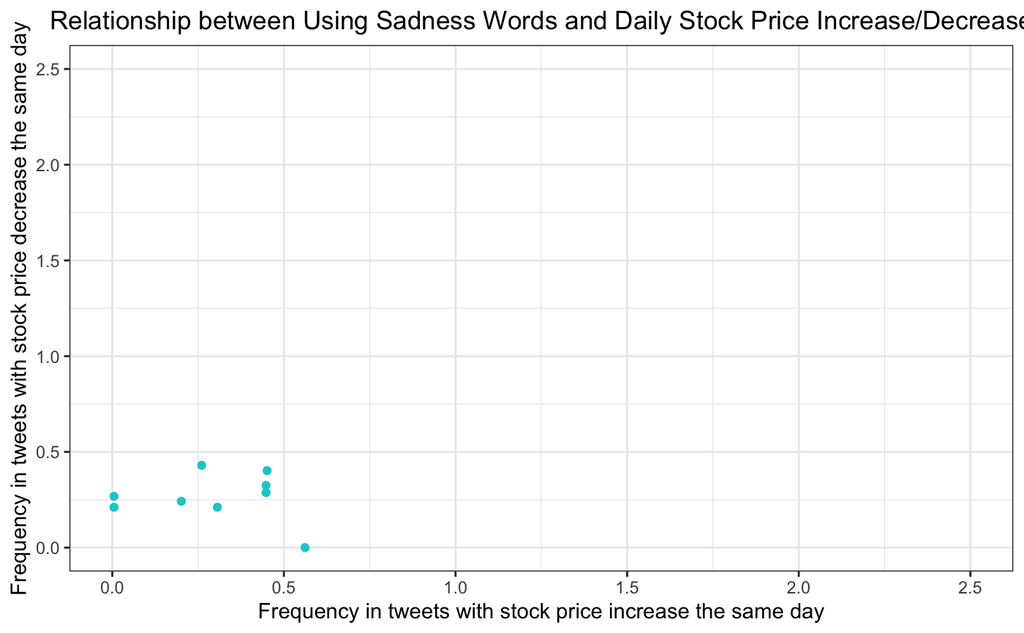

```r
plot7<-sadnesswords %>%
  ggplot(aes(x=i_tf_idf,y=d_tf_idf))+
  geom_jitter(color="#00CED1")+
  theme_bw()+
  theme(legend.position="none")+
  labs(x="Frequency in tweets with stock price increase the same day", y="Frequency in tweets with stock price decrease the same day", title="Relationship between Using Sadness Words and Daily Stock Price Increase/Decrease")+
  theme(plot.title=element_text(hjust=0.5))+
  scale_x_continuous(limits=c(0,2.5), breaks=seq(0,2.5,0.5))+
  scale_y_continuous(limits=c(0,2.5), breaks=seq(0,2.5,0.5))
plot7
```

### Surprise

Find tf_idf score for surprise words used in the tweets.

```r
isurprise<-i_nrc_tf_idf %>%
  filter(term %in% nrc_surprise$word) %>%
  select(term,tf_idf)
isurprise<-rename(isurprise, i_tf_idf=tf_idf)
dsurprise<-d_nrc_tf_idf %>%
  filter(term %in% nrc_surprise$word) %>%
  select(term,tf_idf)
dsurprise<-rename(dsurprise, d_tf_idf=tf_idf)
surprisewords<-full_join(isurprise, dsurprise,by="term")
#Replace all NA values as 0
surprisewords$i_tf_idf[is.na(surprisewords$i_tf_idf)]<-0
surprisewords$d_tf_idf[is.na(surprisewords$d_tf_idf)]<-0
surprisewords
```

| term | i_tf_idf | d_tf_idf |
| --- | --- | --- |
| fortune | 0.6412338 | 0.3300353 |
| trick | 0.6412338 | 0.0000000 |
| hope | 0.5610795 | 0.5995520 |
| hope | 0.5610795 | 0.2997760 |
| dynamic | 0.5610795 | 0.0000000 |
| crash | 0.4488636 | 0.2860306 |
| thrill | 0.4488636 | 0.5139018 |
| thrill | 0.4488636 | 0.1998507 |
| wonderful | 0.4237530 | 0.5319745 |
| wonderful | 0.4237530 | 0.2901679 |

[output cut: 92 more lines]

Visualize the relationship between the use of words from the surprise category and stock price change.

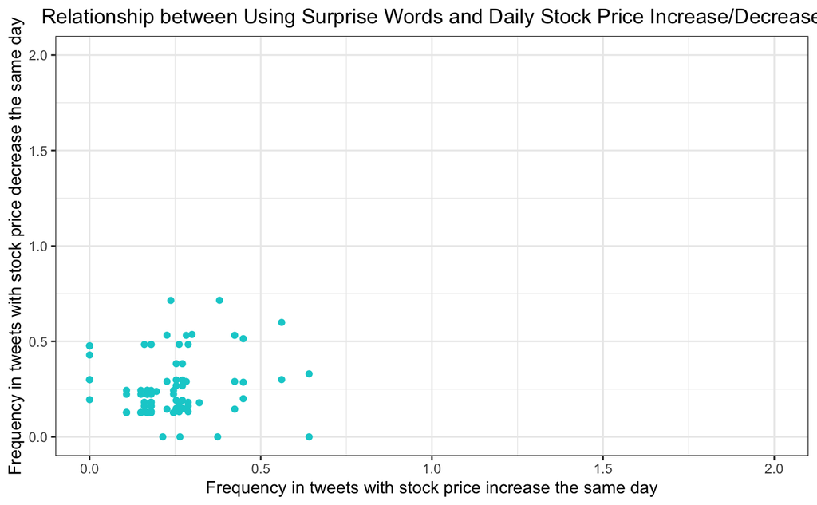

```r
plot8<-surprisewords %>%
  ggplot(aes(x=i_tf_idf,y=d_tf_idf))+
  geom_jitter(color="#00CED1")+
  theme_bw()+
  theme(legend.position="none")+
  labs(x="Frequency in tweets with stock price increase the same day", y="Frequency in tweets with stock price decrease the same day", title="Relationship between Using Surprise Words and Daily Stock Price Increase/Decrease")+
  theme(plot.title=element_text(hjust=0.5))+
  scale_x_continuous(limits=c(0,2), breaks=seq(0,2,0.5))+
  scale_y_continuous(limits=c(0,2), breaks=seq(0,2,0.5))
plot8
```

### Trust

Find tf_idf score for trust words used in the tweets.

```r
itrust<-i_nrc_tf_idf %>%
  filter(term %in% nrc_trust$word) %>%
  select(term,tf_idf)
itrust<-rename(itrust, i_tf_idf=tf_idf)
dtrust<-d_nrc_tf_idf %>%
  filter(term %in% nrc_trust$word) %>%
  select(term,tf_idf)
dtrust<-rename(dtrust, d_tf_idf=tf_idf)
trustwords<-full_join(itrust, dtrust,by="term")
#Replace all NA values as 0
trustwords$i_tf_idf[is.na(trustwords$i_tf_idf)]<-0
trustwords$d_tf_idf[is.na(trustwords$d_tf_idf)]<-0
trustwords
```

| term | i_tf_idf | d_tf_idf |
| --- | --- | --- |
| honor | 0.95973282 | 0.26050548 |
| honor | 0.95973282 | 0.26050548 |
| honor | 0.95973282 | 0.21314084 |
| honor | 0.95973282 | 0.19537911 |
| honor | 0.95973282 | 0.19537911 |
| honor | 0.95973282 | 0.18034995 |
| honor | 0.95973282 | 0.10657042 |
| fortune | 0.64123377 | 0.33003534 |
| hire | 0.64123377 | 0.00000000 |
| hope | 0.56107955 | 0.59955204 |

[output cut: 529 more lines]

Visualize the relationship between the use of words from the trust category and stock price change.

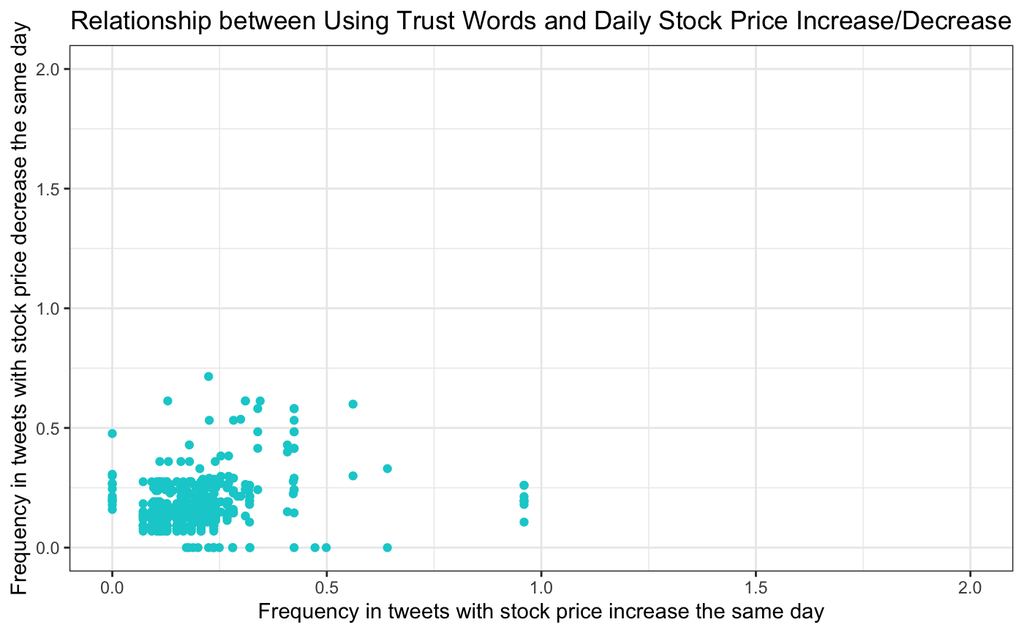

```r
plot9<-trustwords %>%
  ggplot(aes(x=i_tf_idf,y=d_tf_idf))+
  geom_jitter(color="#00CED1")+
  theme_bw()+
  theme(legend.position="none")+
  labs(x="Frequency in tweets with stock price increase the same day", y="Frequency in tweets with stock price decrease the same day", title="Relationship between Using Trust Words and Daily Stock Price Increase/Decrease")+
  theme(plot.title=element_text(hjust=0.5))+
  scale_x_continuous(limits=c(0,2), breaks=seq(0,2,0.5))+
  scale_y_continuous(limits=c(0,2), breaks=seq(0,2,0.5))
plot9
```

### Negative

Find tf_idf score for negative words used in the tweets.

```r
inegative<-i_nrc_tf_idf %>%
  filter(term %in% nrc_negative$word) %>%
  select(term,tf_idf)
inegative<-rename(inegative, i_tf_idf=tf_idf)
dnegative<-d_nrc_tf_idf %>%
  filter(term %in% nrc_negative$word) %>%
  select(term,tf_idf)
dnegative<-rename(dnegative, d_tf_idf=tf_idf)
negativewords<-full_join(inegative, dnegative,by="term")
#Replace all NA values as 0
negativewords$i_tf_idf[is.na(negativewords$i_tf_idf)]<-0
negativewords$d_tf_idf[is.na(negativewords$d_tf_idf)]<-0
negativewords
```

| term | i_tf_idf | d_tf_idf |
| --- | --- | --- |
| challenge | 0.9488723 | 0.0000000 |
| trick | 0.6412338 | 0.0000000 |
| defiance | 0.4987374 | 0.0000000 |
| pandemic | 0.4488636 | 0.0000000 |
| congestion | 0.4488636 | 0.2860306 |
| crash | 0.4488636 | 0.2860306 |
| problem | 0.4488636 | 0.0000000 |
| injured | 0.4080579 | 0.0000000 |
| waste | 0.3452797 | 0.0000000 |
| challenge | 0.3036391 | 0.0000000 |

[output cut: 21 more lines]

Visualize the relationship between the use of words from the negative category and stock price change.

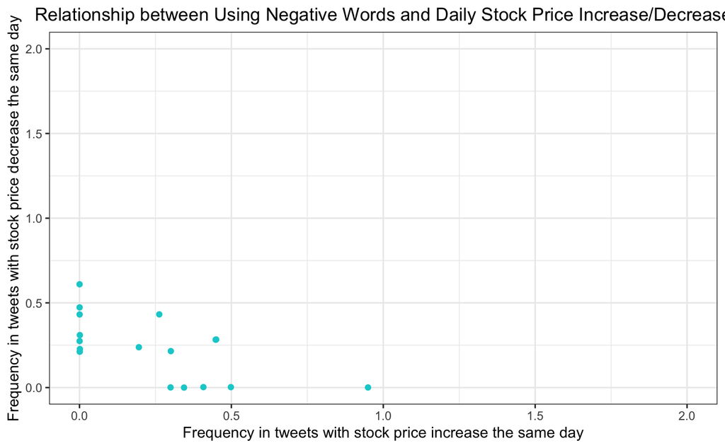

```r
plot10<-negativewords %>%
  ggplot(aes(x=i_tf_idf,y=d_tf_idf))+
  geom_jitter(color="#00CED1")+
  theme_bw()+
  theme(legend.position="none")+
  labs(x="Frequency in tweets with stock price increase the same day", y="Frequency in tweets with stock price decrease the same day", title="Relationship between Using Negative Words and Daily Stock Price Increase/Decrease")+
  theme(plot.title=element_text(hjust=0.5))+
  scale_x_continuous(limits=c(0,2), breaks=seq(0,2,0.5))+
  scale_y_continuous(limits=c(0,2), breaks=seq(0,2,0.5))
plot10
```

### Positive

Find tf_idf score for positive words used in the tweets.

```r
ipositive<-i_nrc_tf_idf %>%
  filter(term %in% nrc_positive$word) %>%
  select(term,tf_idf)
ipositive<-rename(ipositive, i_tf_idf=tf_idf)
dpositive<-d_nrc_tf_idf %>%
  filter(term %in% nrc_positive$word) %>%
  select(term,tf_idf)
dpositive<-rename(dpositive, d_tf_idf=tf_idf)
positivewords<-full_join(ipositive, dpositive,by="term")
#Replace all NA values as 0
positivewords$i_tf_idf[is.na(positivewords$i_tf_idf)]<-0
positivewords$d_tf_idf[is.na(positivewords$d_tf_idf)]<-0
positivewords
```

| term | i_tf_idf | d_tf_idf |
| --- | --- | --- |
| discussion | 1.13000803 | 0.0000000 |
| honor | 0.95973282 | 0.2605055 |
| honor | 0.95973282 | 0.2605055 |
| honor | 0.95973282 | 0.2131408 |
| honor | 0.95973282 | 0.1953791 |
| honor | 0.95973282 | 0.1953791 |
| honor | 0.95973282 | 0.1803499 |
| honor | 0.95973282 | 0.1065704 |
| technology | 0.67800482 | 0.3300353 |
| fortune | 0.64123377 | 0.3300353 |

[output cut: 582 more lines]

```r
plot11<-positivewords %>%
  ggplot(aes(x=i_tf_idf,y=d_tf_idf))+
  geom_jitter(color="#00CED1")+
  theme_bw()+
  theme(legend.position="none")+
  labs(x="Frequency in tweets with stock price increase the same day", y="Frequency in tweets with stock price decrease the same day", title="Relationship between Using Positive Words and Daily Stock Price Increase/Decrease")+
  theme(plot.title=element_text(hjust=0.5))+
  scale_x_continuous(limits=c(0,3), breaks=seq(0,3,0.5))+
  scale_y_continuous(limits=c(0,3), breaks=seq(0,3,0.5))
plot11
```

[output not shown]